# Visualizing and Exploring NYC Parking Violation Data

Peter Silverstein

2025-06-04

This assignment for the QMSS Data Visualization course at Columbia was focused on exploring NYC Parking Violation data, available through the NYC Open Data portal. Note that this assignment was based on a truncated version of the dataset and, thus, results may not match the full set.

# Data Exploration

## Violation Code and Fine Amounts

Add the violation code descriptions and fine amounts to the data file. For simplicity, ignore the differing fine amounts above and below 96th street. Simply use the fine amount for below 96th street for all violations.

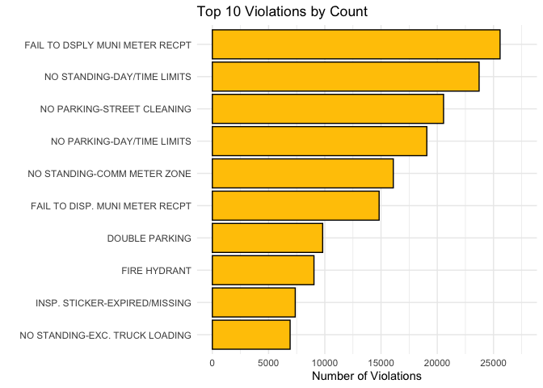

Well, it certainly makes sense that the most common violation was a failure to display the paid parking receipt. I’m going to go ahead and hazard a guess that the primary source of this is not that people paid and simply forgot to display the receipt.

## Average Ticket Amount of Fine by Vehicle

Find an appropriate visualization to show the average amount of fine by vehicle color and vehicle year. Restrict your attention to non-commercial vehicles (see vehicle plate type). Briefly describe your findings.

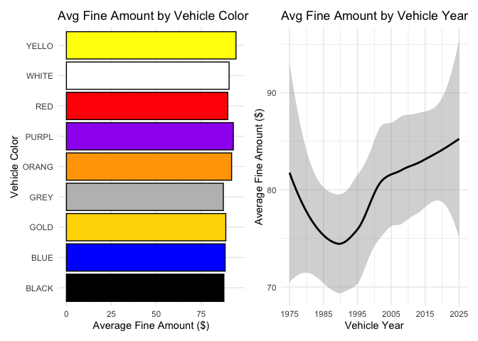

There’s almost no difference by car color, but it does seem like newer cars tend to get higher fines.

# Map by Precincts

Read in the shape files for the police precincts and remove all precincts outside of Manhattan.

## Number of Tickets, Total Fines, and Average Fines

Provide three maps that show choropleth maps of:

- the total number of tickets
- the total amount of fines
- the average amount of fines

Briefly describe what you learn from these maps in comparison. Which of these maps is the most representative of the data?

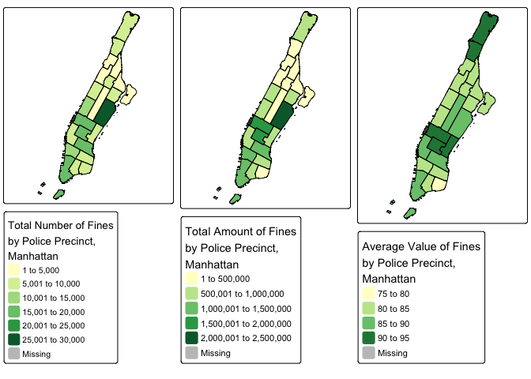

The first thing I learn from these graphs is that the East Side has a lot of tickets that add up to a lot of value, but that the average value of tickets in this area is relatively lower than Midtown or the Fort George/Inwood Hill area. Speaking of, the two precincts at the top of Manhattan show a stark pattern–there aren’t many fines given up there, but they are of high average value. Finally, the pattern in Downtown doesn’t change much across the three maps, which indicates that this area has roughly average total amounts of tickets as well as having those tickets be of roughly average amount.

I would that the first and third maps are more representative of the data than the second. The first one shows raw counts–yes, this doesn’t account for precinct size or population, but it is a useful starting point for examining the data. The third map does scale the reporting value with an average, which helps compare across precincts, regardless of size. My issue with the second is that it reports the data seen in the other two data (total number of tickets * mean ticket amount), but you cannot really pull it apart into those two constituent parts. As such, it is difficult to discern the underlying pattern from this map alone.

# Focus on the Upper East

Precinct 19 identifies the Upper East Side. The data currently does not provide latitude and longitude of the violation locations (and I am not sure what these street_code variables are for).

## Ignoring fire hydrants

Restrict your data to parking violations related to fire hydrants (Violation Code = 40). Using the variables Street Name and House Number as well as the knowledge that these addresses are in the Upper East Side of Manhattan, geocode at least 500 addresses. Include a data table of these addresses and the latitude and longitude of these addresses in the output.

|  | Full Address | Latitude | Longitude |
| --- | --- | --- | --- |
| 1 | N E 83rd St, Upper East Side, Manhattan, New York, NY 10021 | 40.7762824 | -73.9540153 |
| 2 | 527 E 78th St, Upper East Side, Manhattan, New York, NY 10021 | 40.7701001 | -73.9492462 |
| 3 | 513 E 75th St, Upper East Side, Manhattan, New York, NY 10021 | 40.7685446 | -73.9512258 |
| 4 | N E 74th St, Upper East Side, Manhattan, New York, NY 10021 | 40.7709734 | -73.9594307 |
| 5 | 303 E 93rd St, Upper East Side, Manhattan, New York, NY 10021 | 40.7822539 | -73.9479796 |
| 6 | 1768 2nd Ave, Upper East Side, Manhattan, New York, NY 10021 | 40.7817292 | -73.9485368 |
| 7 | 230 E 92nd St, Upper East Side, Manhattan, New York, NY 10021 | 40.7821437 | -73.9502693 |
| 8 | N E 93rd St, Upper East Side, Manhattan, New York, NY 10021 | 40.7841479 | -73.9528374 |
| 9 | 202 E 96th St, Upper East Side, Manhattan, New York, NY 10021 | 40.7849091 | -73.9491451 |
| 10 | 420 E 66th St, Upper East Side, Manhattan, New York, NY 10021 | 40.7633828 | -73.9578261 |

[output cut: 590 more lines]

## Interactive Map

Provide an interactive map of the violations you geocoded using leaflet. Provide at least three pieces of information on the parking ticket in a popup.

[interactive chart not shown]

## Luxury cars

Create another variable called luxury_car in which you identify luxury car brands using the Vehicle Make variable.

Start with the previous map. Distinguish the points by whether the car is a luxury car. Add a legend informing the user about the color scheme. Also make sure that the added information about the car type is now contained in the popup information. Show this map.

[interactive chart not shown]

## Cluster

Add marker clustering, so that zooming in will reveal the individual locations but the zoomed out map only shows the clusters. Show the map with clusters.

[interactive chart not shown]